# Stroop Effect Testing by Ivaylo Sakelariev

In a Stroop task, participants are presented with a list of words, with each word displayed in a color of ink. The participant’s task is to say out loud the color of the ink in which the word is printed. The task has two conditions: a congruent words condition, and an incongruent words condition. In the congruent words condition, the words being displayed are color words whose names match the colors in which they are printed: for example RED, BLUE. In the incongruent words condition, the words displayed are color words whose names do not match the colors in which they are printed: for example PURPLE, ORANGE. In each case, we measure the time it takes to name the ink colors in equally-sized lists. Each participant will go through and record a time from each condition

## My test results:

Congruent words - 11.594 Incongruent words - 28.223

## 1. What is our independent variable? What is our dependent variable?

Independent variable: The condition of the word - congruent or incongruent .

Dependent variable: The time it takes to recognize/name the ink colors of the word.

## 2. What is an appropriate set of hypotheses for this task? What kind of statistical test do you expect to perform? Justify your choices.

Null Hypothsis, H0 - There is no difference between the time used to recognize colors under congruent words condition and incongruent words condition.

Alternative Hypothesis, HA - There is a difference between the time used to recognize colors under congruent words condition and incongruent words condition, namely, the Stroop Effect is in existence.

H0: μi - μc = 0 (μi - population mean of incongruent group, μc - population mean of congruent group)

HA: μi - μc != 0 (μi - population mean of incongruent group, μc - population mean of congruent group)

**Statistical test choices and assumptions**

We can use a two-sided paired student T-test to verify this. There are two reasons for this: first, we need to address the uncertainty in sample standard error resulted from the unknown population standard deviation; second, we are comparing the means of two groups that are dependent.

## 3. Report some descriptive statistics regarding this dataset. Include at least one measure of central tendency and at least one measure of variability.

```r
library(ggplot2)
library(tidyr); suppressMessages(library(dplyr))
#Loading the data
stroop = read.csv("stroopdata.csv")
head(stroop,24)
```

|  | Congruent | Incongruent |
| --- | --- | --- |
| 1 | 12.079 | 19.278 |
| 2 | 16.791 | 18.741 |
| 3 | 9.564 | 21.214 |
| 4 | 8.630 | 15.687 |
| 5 | 14.669 | 22.803 |
| 6 | 12.238 | 20.878 |
| 7 | 14.692 | 24.572 |
| 8 | 8.987 | 17.394 |
| 9 | 9.401 | 20.762 |
| 10 | 14.480 | 26.282 |

[output cut: 14 more lines]

```r
stroop.subject <- mutate(stroop, subject = 1:nrow(stroop))
tidy.stroop <- gather(stroop.subject, congruency, time, -subject)
```

```r
#Summary of the dataset - Mean, Median...
summary(stroop)
```

```
   Congruent      Incongruent
 Min.   : 8.63   Min.   :15.69
 1st Qu.:11.90   1st Qu.:18.72
 Median :14.36   Median :21.02
 Mean   :14.05   Mean   :22.02
 3rd Qu.:16.20   3rd Qu.:24.05
 Max.   :22.33   Max.   :35.26
```

```r
#Standard Deviation of Congruent
sd(stroop$Congruent)
```

```
[1] 3.559358
```

```r
#Standard Deviation of Incongruent
sd(stroop$Incongruent)
```

```
[1] 4.797057
```

**Sample size** = 24

Standard Deviation of Congruent = 3.559358 Standard Deviation of Incongruent = 4.797057

## 4. Provide one or two visualizations that show the distribution of the sample data. Write one or two sentences noting what you observe about the plot or plots.

**Plots** I decide to create two plots of the distributions of the data of both congruent and incongruent conditions - a histogram and a boxplot chart.

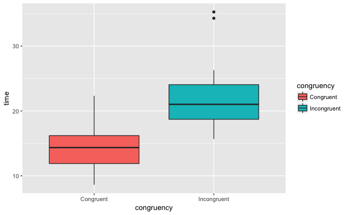

```r
ggplot(tidy.stroop, aes(y = time, x = congruency, fill = congruency))+
  geom_boxplot()
```

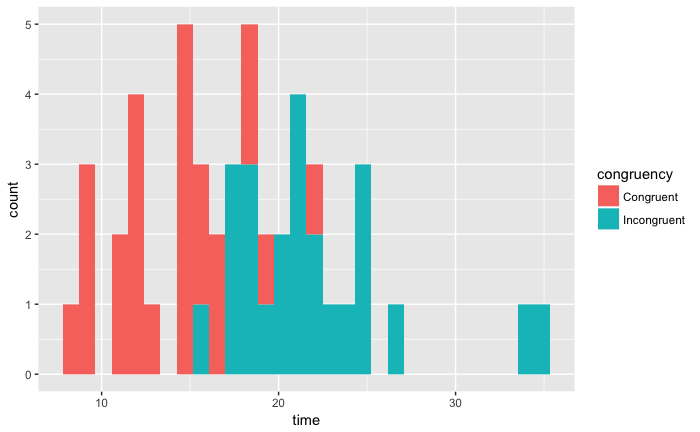

```r
ggplot(tidy.stroop, aes(x = time, fill = congruency)) +
  geom_histogram()
```

**Observations** From the boxplots it’s obvious that the Incongruent words group have a significant higher median, mean and dsitrbutions than the Congruent words group. We also see that there are two outliers in the Incongruent group.

The histograms confirm that observation.

## 5. Now, perform the statistical test and report your results. What is your confidence level and your critical statistic value? Do you reject the null hypothesis or fail to reject it? Come to a conclusion in terms of the experiment task. Did the results match up with your expectations?

```r
# H0: m_diff = 0 (μi - μc = 0)
# HA: m_diff != 0 (μi - μc != 0)
mu_diff <- 0
stroop.diff <- mutate(stroop.subject, diff = Congruent - Incongruent) # add a new diff column
diff <- stroop.diff$diff # grab all the diff values into a vector
sigma <- sd(diff) # sample sd
diff_bar <- mean(diff) # sample mean
n <- length(diff) # sample size
DF <- n - 1 # degree of freedom
SE <- sigma/sqrt(n) # standard error
# Calculate the T-statistic:
T <- (diff_bar- mu_diff)/SE; T
```

```
[1] -8.020707
```

```r
# Calculating the p-value
p_value <- pt(T, df = DF, lower.tail = TRUE) * 2; p_value
```

```
[1] 4.103001e-08
```

```r
# Building the confidence interval based on 5% confidence level
diff_bar + c(1, -1) * qt(.975, df = DF, lower.tail = FALSE) * SE
```

```
[1] -10.019028  -5.910555
```

```r
# Verifying using the t.test() function
t.test(x=stroop$Congruent, y=stroop$Incongruent, alternative = "two.sided", mu = 0, paired = TRUE, conf.level = 0.95)
```

```
    Paired t-test

data:  stroop$Congruent and stroop$Incongruent
t = -8.0207, df = 23, p-value = 4.103e-08
alternative hypothesis: true difference in means is not equal to 0
95 percent confidence interval:
 -10.019028  -5.910555
sample estimates:
mean of the differences
              -7.964792
```

Since the p-value is less than 0.05, we reject the null hypothesis and conclude that the difference between congruence and incongruence group time difference is statistically significant, which means that the Stroop effect is present. This is what I expected as a result.

We’re 95% confident that the true difference between the congruence and incongruence group average times is between -10.019028 and -5.910555.

## Reference

https://en.wikipedia.org/wiki/Stroop_effect

http://ggplot2.tidyverse.org/

https://www.rstudio.com/wp-content/uploads/2015/02/data-wrangling-cheatsheet.pdf